# Analysis of longitudal data

Savi Virolainen

11/30/2020

# Analysis of longitudal data

## Implementing the analyses of Chapter 8 of MABS using RATS data

Load the data:

```r
RATS <- read.csv("data/RATS.csv")
RATSL <- read.csv("data/RATSL.csv")

# ID and Group as factors (they were transformed back to int when reading):
RATSL$ID <- factor(RATSL$ID)
RATSL$Group <- factor(RATSL$Group)
```

### Introduction

Table of wide RATS data:

```r
head(RATS, n=nrow(RATS))
```

```
##    ID Group WD1 WD8 WD15 WD22 WD29 WD36 WD43 WD44 WD50 WD57 WD64
## 1   1     1 240 250  255  260  262  258  266  266  265  272  278
## 2   2     1 225 230  230  232  240  240  243  244  238  247  245
## 3   3     1 245 250  250  255  262  265  267  267  264  268  269
## 4   4     1 260 255  255  265  265  268  270  272  274  273  275
## 5   5     1 255 260  255  270  270  273  274  273  276  278  280
## 6   6     1 260 265  270  275  275  277  278  278  284  279  281
## 7   7     1 275 275  260  270  273  274  276  271  282  281  284
## 8   8     1 245 255  260  268  270  265  265  267  273  274  278
## 9   9     2 410 415  425  428  438  443  442  446  456  468  478
## 10 10     2 405 420  430  440  448  460  458  464  475  484  496
## 11 11     2 445 445  450  452  455  455  451  450  462  466  472
## 12 12     2 555 560  565  580  590  597  595  595  612  618  628
## 13 13     3 470 465  475  485  487  493  493  504  507  518  525
## 14 14     3 535 525  530  533  535  540  525  530  543  544  559
## 15 15     3 520 525  530  540  543  546  538  544  553  555  548
## 16 16     3 510 510  520  515  530  538  535  542  550  553  569
```

### Graphical displays of longitudal data

The RATS data contains measured body weights of rats in different points of time where the rats are divided into three groups. For each of the three groupS, different diets were fed to the rats. We examine the data graphically where the three groups are presented in different figures where the body weight is in the vertical axis and time in the horizontal axis:

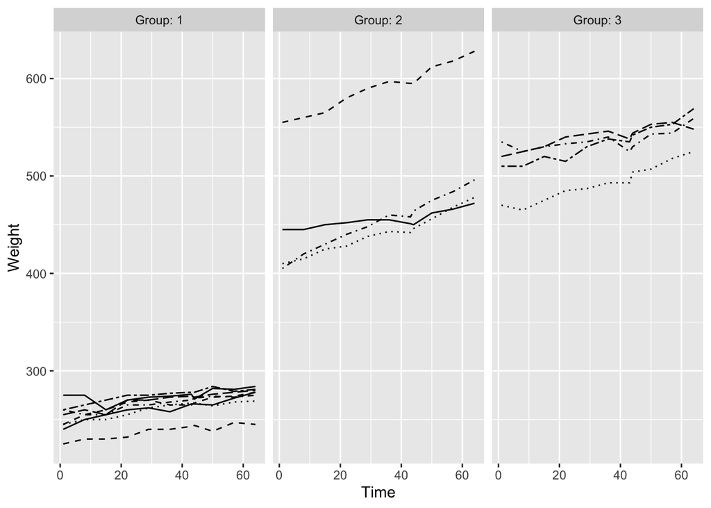

```r
library(ggplot2)
library(dplyr)

ggplot(RATSL, aes(x = Time, y = Weight, linetype = ID)) +
  geom_line() +
  scale_linetype_manual(values = rep(1:10, times=4)) +
  facet_grid(. ~ Group, labeller = label_both) +
  theme(legend.position = "none") +
  scale_y_continuous(limits = c(min(RATSL$Weight), max(RATSL$Weight)))
```

Two kind of patterns are apparent for all groups: the weight seems to increase as a function of time and rats with higher starting weight typically have higher weight throughout the study. This is often referred to as tracking. The ordering of the final weights is not, however, the same as the ordering of the starting weights in our RATS data.

We then do the same graphical examination but with standardized data (=centered and divided by standard deviation):

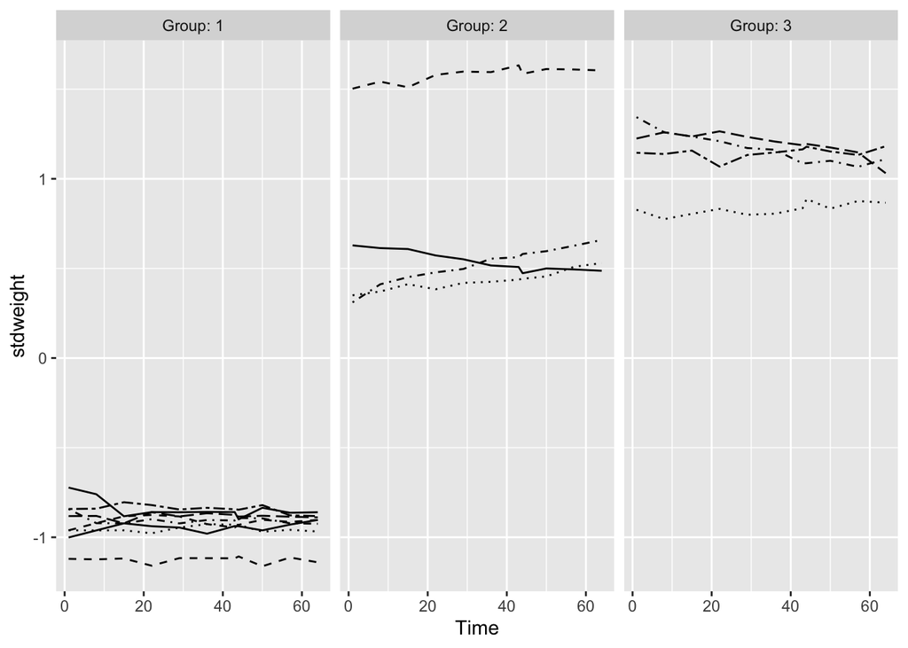

```r
# Create standardized weights
RATSL <- RATSL %>%
  group_by(Time) %>%
  mutate(stdweight = (Weight - mean(Weight))/sd(Weight)) %>%
  ungroup()

# Plot the standardized weights
ggplot(RATSL, aes(x = Time, y = stdweight, linetype = ID)) +
  geom_line() +
  scale_linetype_manual(values = rep(1:10, times=4)) +
  facet_grid(. ~ Group, labeller = label_both) +
  theme(legend.position = "none") +
  scale_y_continuous(limits = c(min(RATSL$stdweight), max(RATSL$stdweight)))
```

One may observe the tracking phenomenom from the above standardized data summary plot as well.

### Summary measure analysis of longitudal data

We draw a summary figure and plot the mean profiles with one standard error bounds:

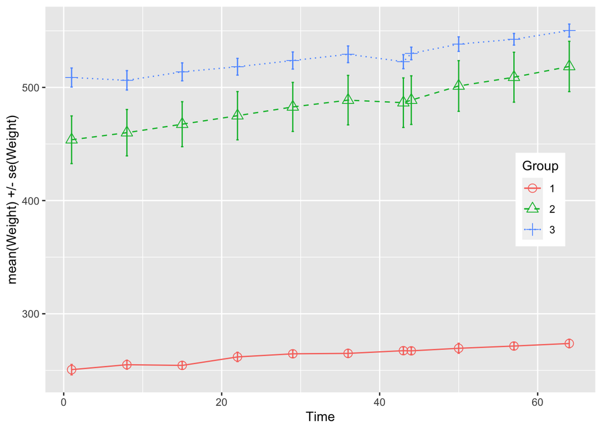

```r
RATSS <- RATSL %>%
  group_by(Group, Time) %>%
  summarise(mean = mean(Weight), se = sd(Weight)/sqrt(length(unique(RATSL$Time)))) %>%
  ungroup()

ggplot(RATSS, aes(x = Time, y = mean, linetype = Group, shape = Group, color=Group)) +
  geom_line() +
  scale_linetype_manual(values = c(1, 2, 3)) +
  geom_point(size=3) +
  scale_shape_manual(values = c(1, 2, 3)) +
  geom_errorbar(aes(ymin=mean-se, ymax=mean+se, linetype="1"), width=0.3) +
  theme(legend.position = c(0.9, 0.5)) +
  scale_y_continuous(name = "mean(Weight) +/- se(Weight)")
```

The weights seem to be generally increasing in time, the slowest in group 1, the next slowest in group 3, and the fastest in group 2. Also, there seems to be least variation in weights within the first group, a bit more in the third group, while in group 2 there is most variation in the weights. One standard error bounds don’t cross in any of the groups so the mean weights seem to generally differ between the groups at all time points.

Then we draw another kind of summary figure, now using boxplots for the weights:

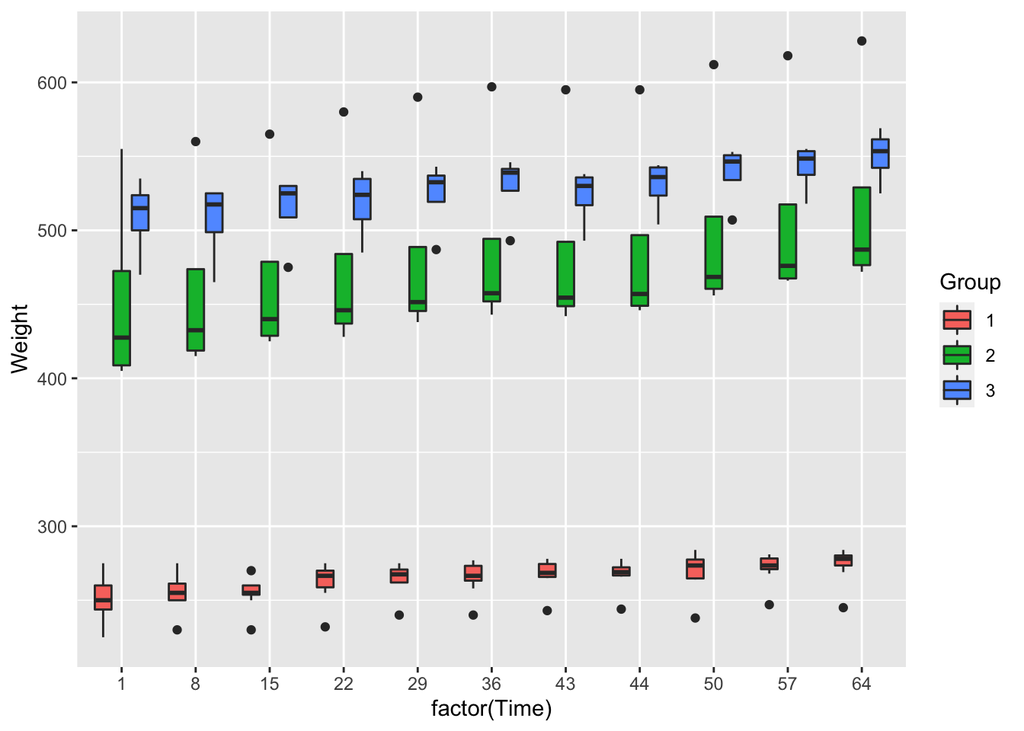

```r
ggplot(RATSL, aes(x = factor(Time), y = Weight, fill=Group)) +
  geom_boxplot()
```

One may observe presence of some outliers in all the groups with the most serious one in group 2. This outlier can be easily detected from the first summary plot as well where one of the rats in group 2 has much higher weight that the other rats in the group. The weights seem to be generally increasing in time with the least within group variation in group 1, and little within group variation in group 3 as well but more within group variation in group 2. Because the medians are generally not in the middle, the weight distributions seem skewed.

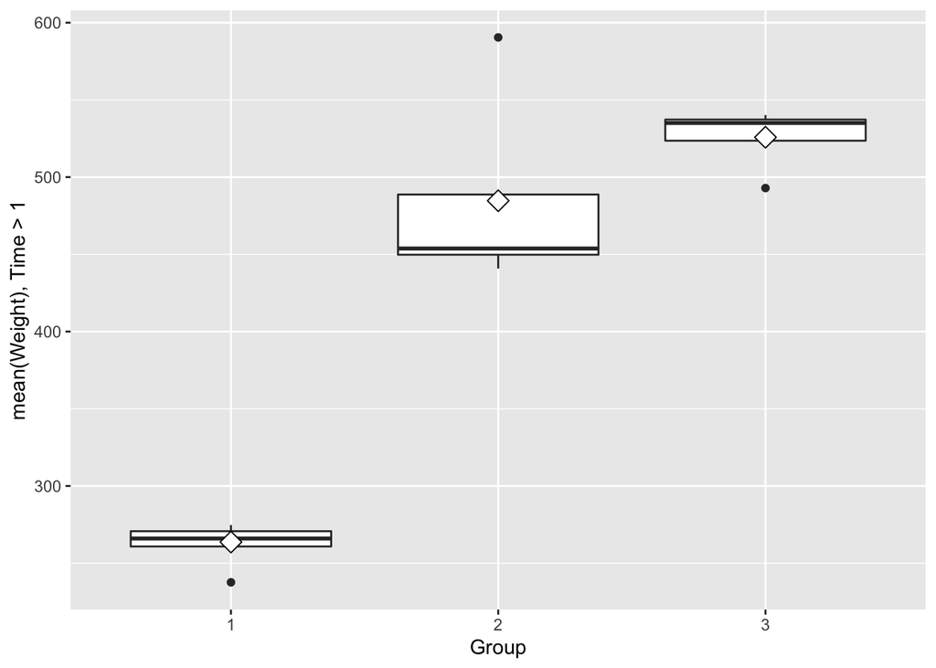

```r
# Remove the initial time point:
RATSS2 <- RATSL %>%
  filter(Time > 0) %>%
  group_by(Group, ID) %>%
  summarise(mean=mean(Weight)) %>%
  ungroup()

# Function to draw a boxplot:
draw_bp <- function(dat) {
  ggplot(dat, aes(x = Group, y = mean)) +
  geom_boxplot() +
  stat_summary(fun = "mean", geom = "point", shape=23, size=4, fill = "white") +
  scale_y_continuous(name = "mean(Weight), Time > 1")
}

# Boxplot:
draw_bp(RATSS2)
```

It seems the the first group has smaller means than the other two groups. The difference is smaller between groups 2 and 3 but still the means of the second group seem significantly smaller than the one of the third group, as besides a single outlier, the group 2’s mean weights are smaller than group 3’s mean weights.

Following the book, we remove the substantial outlier in group 2 that may significantly alter the results and draw the boxplot again. There are also single outliers in groups 1 and 3 but they don’t seem too serious so we will not exclude them (there is no reason to just exclude everything a boxplot classifies as an outlier).

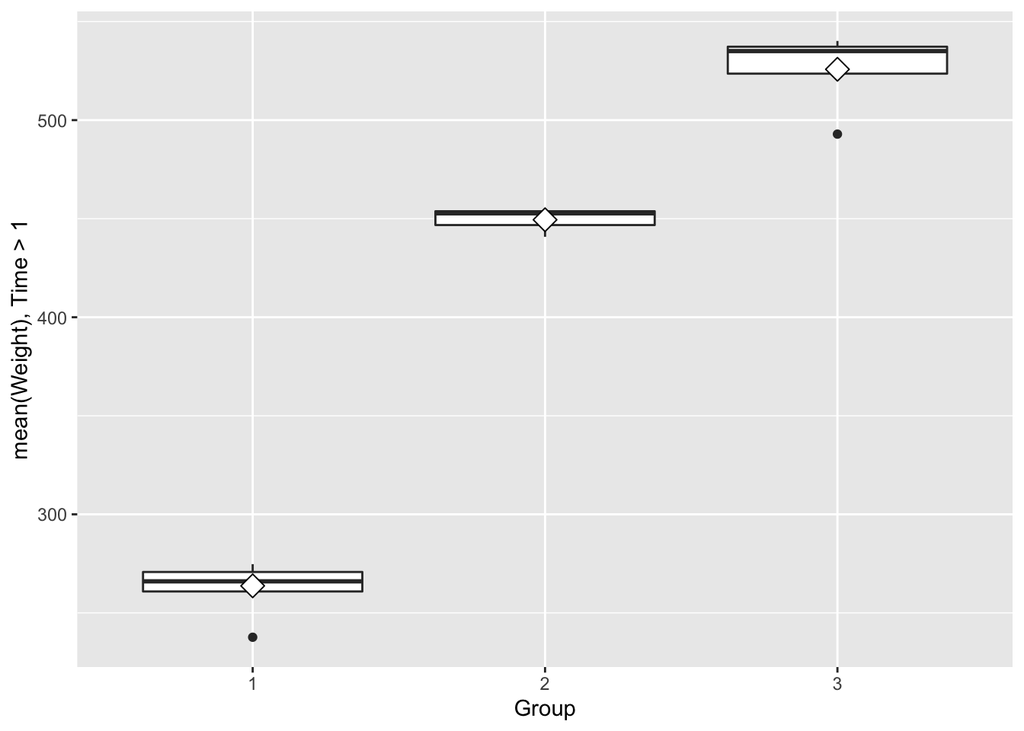

```r
RATSS3 <- filter(RATSS2, mean < 550)
draw_bp(RATSS3)
```

Now the difference between the second and third groups is more apparent.

We formally test the group difference using two-sample t-tests without the outlier:

```r
t.test(mean ~ Group, data = filter(RATSS3, Group %in% c(1, 2)), var.equal=FALSE) # Groups 1 and 2
```

```
##
##  Welch Two Sample t-test
##
## data:  mean by Group
## t = -30.709, df = 5.9527, p-value = 8.748e-08
## alternative hypothesis: true difference in means is not equal to 0
## 95 percent confidence interval:
##  -200.5669 -170.9104
## sample estimates:
## mean in group 1 mean in group 2
##        263.7159        449.4545
```

```r
t.test(mean ~ Group, data = filter(RATSS3, Group %in% c(1, 3)), var.equal=FALSE) # Groups 1 and 3
```

```
##
##  Welch Two Sample t-test
##
## data:  mean by Group
## t = -22.193, df = 3.8927, p-value = 3.035e-05
## alternative hypothesis: true difference in means is not equal to 0
## 95 percent confidence interval:
##  -295.2267 -228.9324
## sample estimates:
## mean in group 1 mean in group 3
##        263.7159        525.7955
```

```r
t.test(mean ~ Group, data = filter(RATSS3, Group %in% c(2, 3)), var.equal=FALSE) # Groups 2 and 3
```

```
##
##  Welch Two Sample t-test
##
## data:  mean by Group
## t = -6.4314, df = 3.8677, p-value = 0.003371
## alternative hypothesis: true difference in means is not equal to 0
## 95 percent confidence interval:
##  -109.74659  -42.93523
## sample estimates:
## mean in group 2 mean in group 3
##        449.4545        525.7955
```

The small p-values indicate that the mean weights of all the groups are most likely different. The above printout also shows the means of the different groups and confidence intervals the difference of the means.

```r
RATSS4 <- mutate(RATSS2, baseline=RATS$WD1)
fit <- lm(mean ~ baseline + Group, data=RATSS4)
anova(fit)
```

```
## Analysis of Variance Table
##
## Response: mean
##           Df Sum Sq Mean Sq   F value    Pr(>F)
## baseline   1 252125  252125 2237.0655 5.217e-15 ***
## Group      2    726     363    3.2219   0.07586 .
## Residuals 12   1352     113
## ---
## Signif. codes:  0 '***' 0.001 '**' 0.01 '*' 0.05 '.' 0.1 ' ' 1
```

As the above summary printout of anova shows, the baseline weight is strongly related to the weights recorded after following the diet (as was also concluded from the graphical summaries already). The group variable has some (but not very strong) statistical significance as well, indicating that the different diets may as well be related to the different weights recorded. Recall that the weight gaining speeds were noted to differ a bit between the groups in the earlier graphical summaries, being in line with the results from anova.

We don’t have missing values in the data, so that part of the book’s chapter 8 wont be replicated here.

## Implementing the analyses of Chapter 9 of MABS using BPRS data

Load the data:

```r
BPRS <- read.csv("data/BPRS.csv")
BPRSL <- read.csv("data/BPRSL.csv")

# Treatment, subject, and ID as factors (they were transformed back to int when reading):
BPRSL$treatment <- factor(BPRSL$treatment)
BPRSL$subject <- factor(BPRSL$subject)
BPRSL$ID <- factor(BPRSL$ID)
```

### How Do Rats Grow? (with BPRS data)

Table of wide form BPRS data:

```r
head(BPRS, n=nrow(BPRS))
```

```
##    treatment subject week0 week1 week2 week3 week4 week5 week6 week7 week8 ID
## 1          1       1    42    36    36    43    41    40    38    47    51  1
## 2          1       2    58    68    61    55    43    34    28    28    28  2
## 3          1       3    54    55    41    38    43    28    29    25    24  3
## 4          1       4    55    77    49    54    56    50    47    42    46  4
## 5          1       5    72    75    72    65    50    39    32    38    32  5
## 6          1       6    48    43    41    38    36    29    33    27    25  6
## 7          1       7    71    61    47    30    27    40    30    31    31  7
## 8          1       8    30    36    38    38    31    26    26    25    24  8
## 9          1       9    41    43    39    35    28    22    20    23    21  9
## 10         1      10    57    51    51    55    53    43    43    39    32 10
## 11         1      11    30    34    34    41    36    36    38    36    36 11
## 12         1      12    55    52    49    54    48    43    37    36    31 12
## 13         1      13    36    32    36    31    25    25    21    19    22 13
## 14         1      14    38    35    36    34    25    27    25    26    26 14
```

[output cut: 26 more lines]

Table of long from BPRS data for the baseline week;

```r
head(BPRSL, n=40)
```

```
##    treatment subject ID weeks bprs week
## 1          1       1  1 week0   42    0
## 2          1       2  2 week0   58    0
## 3          1       3  3 week0   54    0
## 4          1       4  4 week0   55    0
## 5          1       5  5 week0   72    0
## 6          1       6  6 week0   48    0
## 7          1       7  7 week0   71    0
## 8          1       8  8 week0   30    0
## 9          1       9  9 week0   41    0
## 10         1      10 10 week0   57    0
## 11         1      11 11 week0   30    0
## 12         1      12 12 week0   55    0
## 13         1      13 13 week0   36    0
## 14         1      14 14 week0   38    0
```

[output cut: 26 more lines]

Plot of bprs against week (time) for BPRS data, ignoring the repeated-measures structure of the data (the week variable is jittered to reveal overlapping observations):

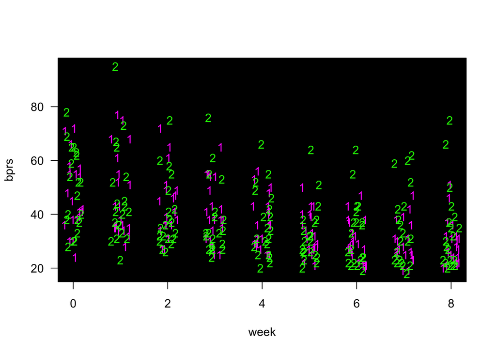

```r
with(BPRSL, plot(c(min(week), max(week)), c(min(bprs), max(bprs)), type="n", ylab="bprs",
                 xlab="week", las=1))
rect(col="black", -10, -10, 10, 100)
with(BPRSL, points(y=bprs, x=jitter(week), pch=c("1", "2")[treatment],
                   col=c("magenta", "green")[treatment], cex=1))
```

Then we create a graphical display of the data that takes into account the longitudal structure:

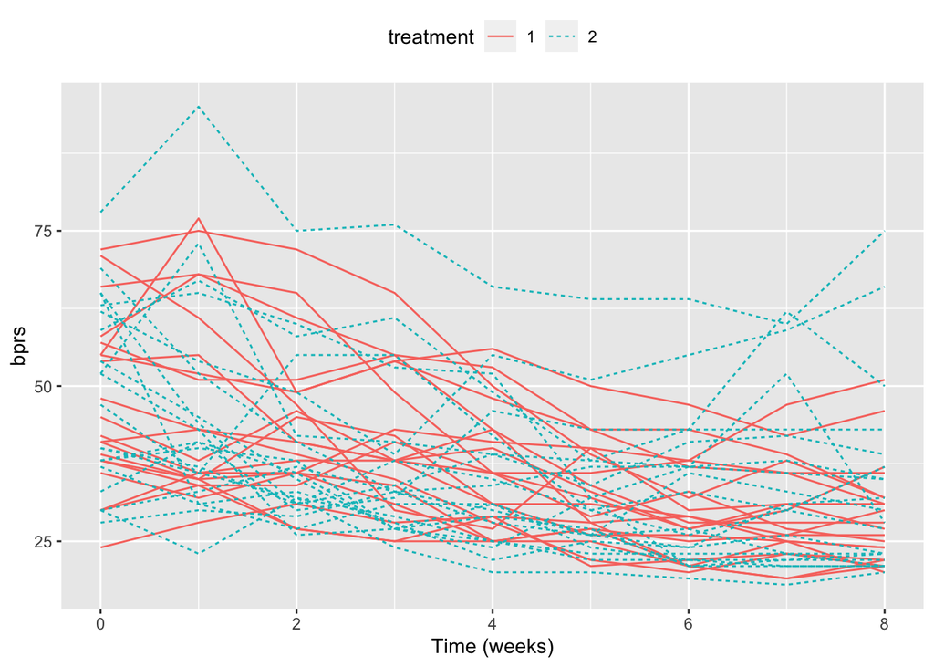

```r
# NOTE THAT WE CREATED THE ID VARIABLE IN THE WRANGLING PART
p1 <- ggplot(BPRSL, aes(x = week, y = bprs, group=ID)) +
        geom_line(aes(color=treatment, linetype=treatment)) +
        scale_x_continuous(name = "Time (weeks)", breaks = seq(0, 8, by=2)) +
        scale_y_continuous(name = "bprs") +
        theme(legend.position = "top")
p1
```

The above figure shows the individual subjects’ bprs profiles. The bprs seems to be generally decreasing slightly but it is difficult to detect any apparent differences between the two treatments.

Scatter plot matrix of repreated measures in BPRS data:

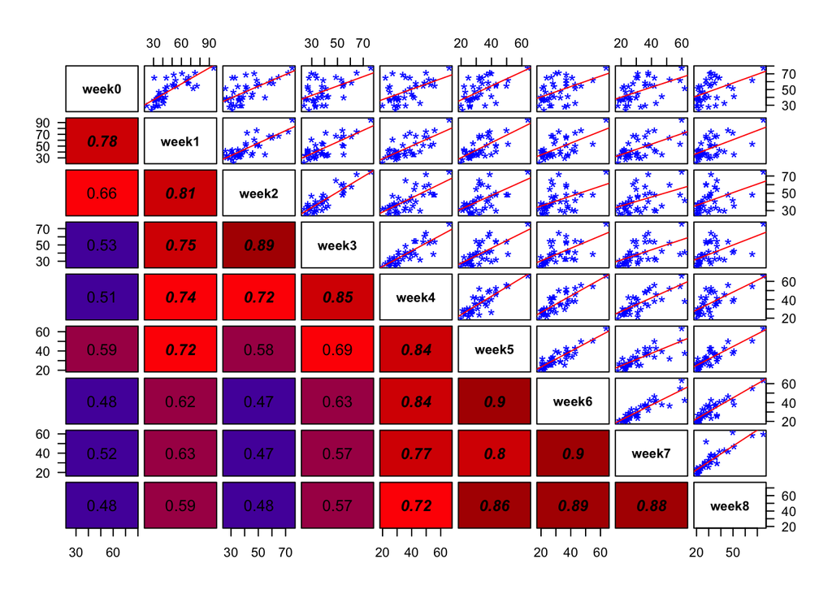

```r
par(las=1)
pairs(BPRS[,3:11], gap=0.4, font.labels=2, cex.labels=1, panel=function(x, y) {
  points(x, y, col="blue", pch="*", cex=1.5)
  abline(lm(y ~ x), col="red")
  },
  lower.panel=function(x, y) {
    old_par <- par(no.readonly=TRUE)
    on.exit(old_par)
    par(usr=c(0, 1, 0, 1))
    ncol <- 10
    colpal <- colorRampPalette(c("skyblue", "blue", "red", "red4"))(ncol)
    corcol <- abs(round(ncol*cor(x, y)))
    do.call(rect, c(col=colpal[corcol], list(0, 0, 1, 1)))
    text(x=0.5, y=0.5, labels=round(cor(x, y), 2), font=ifelse(abs(cor(x, y)) > 0.7, 4, 1),
         cex=1.2)
  })
```

We fit linear regression model via OLS to the BPRS data with bprs as response, and treatment and week (time) as explanatory variables, and ignoring the repeated measures structure of the data:

```r
summary(lm(bprs ~ treatment + week, data=BPRSL))
```

```
##
## Call:
## lm(formula = bprs ~ treatment + week, data = BPRSL)
##
## Residuals:
##     Min      1Q  Median      3Q     Max
## -22.454  -8.965  -3.196   7.002  50.244
##
## Coefficients:
##             Estimate Std. Error t value Pr(>|t|)
## (Intercept)  46.4539     1.3670  33.982   <2e-16 ***
## treatment2    0.5722     1.3034   0.439    0.661
## week         -2.2704     0.2524  -8.995   <2e-16 ***
## ---
## Signif. codes:  0 '***' 0.001 '**' 0.01 '*' 0.05 '.' 0.1 ' ' 1
##
## Residual standard error: 12.37 on 357 degrees of freedom
## Multiple R-squared:  0.1851, Adjusted R-squared:  0.1806
## F-statistic: 40.55 on 2 and 357 DF,  p-value: < 2.2e-16
```

According to the t-tests, treatment does not seem to have statistically significant effect on the response but the time variable (week) definitely does.

Next, we fit the random intercepts model and examine the summary printout:

```r
library(lme4)
fit1 <- lmer(bprs ~ week + treatment + (1 | ID), data = BPRSL, REML = FALSE)
summary(fit1)
```

```
## Linear mixed model fit by maximum likelihood  ['lmerMod']
## Formula: bprs ~ week + treatment + (1 | ID)
##    Data: BPRSL
##
##      AIC      BIC   logLik deviance df.resid
##   2582.9   2602.3  -1286.5   2572.9      355
##
## Scaled residuals:
##      Min       1Q   Median       3Q      Max
## -2.27506 -0.59909 -0.06104  0.44226  3.15835
##
## Random effects:
##  Groups   Name        Variance Std.Dev.
##  ID       (Intercept) 97.39    9.869
##  Residual             54.23    7.364
## Number of obs: 360, groups:  ID, 40
##
## Fixed effects:
##             Estimate Std. Error t value
## (Intercept)  46.4539     2.3521  19.750
## week         -2.2704     0.1503 -15.104
## treatment2    0.5722     3.2159   0.178
##
## Correlation of Fixed Effects:
##            (Intr) week
## week       -0.256
## treatment2 -0.684  0.000
```

Focusing on the fixed effects, the small t-value of “treatment2” indicates that there is no statistically significant difference in the intercepts for observations with different treatments. The week variable with negative coefficient has large t-value which implies that the bprs seems to generally decrease as the time passes in the experiment, as was concluded from the grapchical summary as well. Focusing then on the random effects, the variance and standard deviations of the random effect intercepts is quite large, which tells that the individuals seem to have quite different intercepts (=starting bprs scores) in general.

Then we fit a random intercept and slope model with week and treatment as explanatory variables and examine the summary printout:

```r
fit2 <- lmer(bprs ~ week + treatment + (week | ID), data = BPRSL, REML = FALSE)
summary(fit2)
```

```
## Linear mixed model fit by maximum likelihood  ['lmerMod']
## Formula: bprs ~ week + treatment + (week | ID)
##    Data: BPRSL
##
##      AIC      BIC   logLik deviance df.resid
##   2523.2   2550.4  -1254.6   2509.2      353
##
## Scaled residuals:
##     Min      1Q  Median      3Q     Max
## -2.4655 -0.5150 -0.0920  0.4347  3.7353
##
## Random effects:
##  Groups   Name        Variance Std.Dev. Corr
##  ID       (Intercept) 167.827  12.955
##           week          2.331   1.527   -0.67
##  Residual              36.747   6.062
## Number of obs: 360, groups:  ID, 40
##
## Fixed effects:
##             Estimate Std. Error t value
## (Intercept)  45.9830     2.6470  17.372
## week         -2.2704     0.2713  -8.370
## treatment2    1.5139     3.1392   0.482
##
## Correlation of Fixed Effects:
##            (Intr) week
## week       -0.545
## treatment2 -0.593  0.000
```

Focusing on the random effects, notice that the variance of the random intercepts increased while the variance for the random slope also seems relative large. Focusing then on the fixed effects, the week parameter with negative coefficient estimate has a large t-value, so also in this model the bprs score seems to decrease over time. The t-value for the treatment coefficient is still small, indicating that there is no statistically significant difference between in the fixed effects intercepts in the two treatments.

Next, we estimate a random intercept and random slope model that also allows for interactions between the treatment and week variable. That is, subjects with different treatments may have different fixed effect slopes. We also examine the summary printout:

```r
fit3 <- lmer(bprs ~ week*treatment + (week | ID), data = BPRSL, REML = FALSE)
summary(fit3)
```

```
## Linear mixed model fit by maximum likelihood  ['lmerMod']
## Formula: bprs ~ week * treatment + (week | ID)
##    Data: BPRSL
##
##      AIC      BIC   logLik deviance df.resid
##   2523.5   2554.5  -1253.7   2507.5      352
##
## Scaled residuals:
##     Min      1Q  Median      3Q     Max
## -2.4747 -0.5256 -0.0866  0.4435  3.7884
##
## Random effects:
##  Groups   Name        Variance Std.Dev. Corr
##  ID       (Intercept) 164.204  12.814
##           week          2.203   1.484   -0.66
##  Residual              36.748   6.062
## Number of obs: 360, groups:  ID, 40
##
## Fixed effects:
##                 Estimate Std. Error t value
## (Intercept)      47.8856     2.9840  16.047
## week             -2.6283     0.3752  -7.006
## treatment2       -2.2911     4.2200  -0.543
## week:treatment2   0.7158     0.5306   1.349
##
## Correlation of Fixed Effects:
##             (Intr) week   trtmn2
## week        -0.668
## treatment2  -0.707  0.473
## wek:trtmnt2  0.473 -0.707 -0.668
```

Focusing on the random effects, the variances of the random intercepts and slopes remained approximately the same compared to the model without interactions. Focusing then on the fixed effects, the week variable still has statistically significant negative coefficient. The treatment2-intercept, however, now became negative when it was positive before, but its t-value is still too close to zero to declare any statistical significance. The interaction between week and treatment has t-value 1.349 which implies the approximate p-value

```r
2*(1 - pnorm(1.349))
```

```
## [1] 0.177337
```

for the null hypothesis that the interaction is zero. The interaction is more statistically significant than the intercept difference of treatments (which may be included to control for different starting scores in the two groups) but due to the large p-value we cannot say with great certainty that the bprs scores decrease with different speed for subjects with different treatments. The point estimate, nonetheless, implies that the bprs score decreases less over time for subjects with treatment 2 than with treatment 1.

After examining the summary printout, we visualize the model with random intercepts and slopes as well as fixed effects interaction for treatment and time slope. We also plot the observed values next to the fitted values.

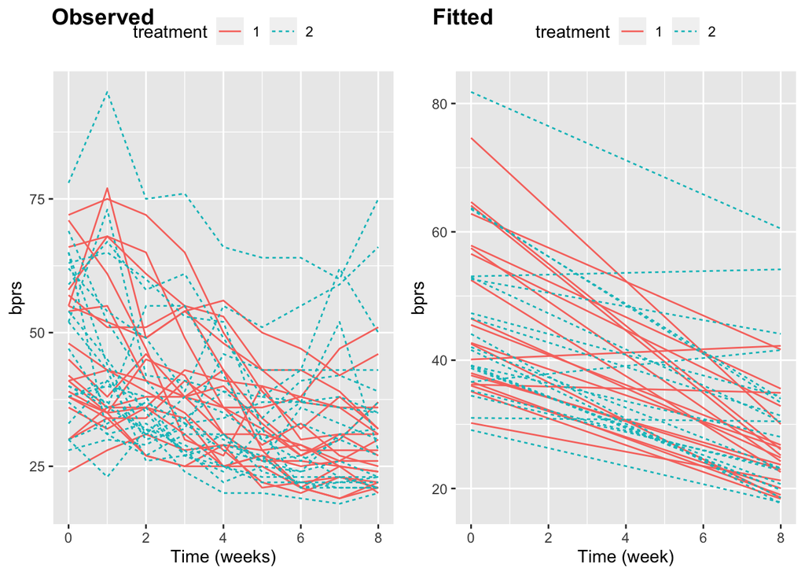

```r
library(ggplot2)
library(ggpubr)
BPRSL <- mutate(BPRSL, Fitted=fitted(fit3)) # Add the fitted values to the data

p2 <- ggplot(BPRSL, aes(x = week, y = Fitted, group = ID)) +
        geom_line(aes(linetype = treatment, color=treatment)) +
        scale_x_continuous(name = "Time (week)", breaks = seq(0, 8, by=2)) +
        scale_y_continuous(name = "bprs") +
        theme(legend.position = "top")
ggarrange(p1, p2, labels=c("Observed", "Fitted"), ncol=2, nrow=1)
```

Looking at the fitted values, the conclusions from the summary printout are apparent also in the plot: the intercepts do not in average seem to be much different for the two treatments, while bprs seems to decrease on average a bit faster with the first treatment but the difference is not very large. Also, some of the slopes are positive and not negative.

I suppose replicating Section 9.4 considering the BtB data is not necessary as we already did the similar things with the BPRS data.